# Introduction

If we sum all of the single cells together, does it act like having run the bulk single cell pipeline on the concatination of all the single cell reads.

Throughout this notebook "sc" stands for a sum of all the single cell libraries and "population" refers to pooling the single cell fastqs and feeding the combined fastq through the standarded encode bulk RNA-seq pipeline.

Given a single cell "genes" by "cell" matrix like the following, I calculate the sum along the gene axis.

$\sum_{i=0}^{c} \begin{pmatrix} x_{00} & x_{01} & \ldots & x_{0c} \\ x_{10} & x_{11} & \ldots & x_{1c} \\ \vdots & \vdots & \ddots & \vdots \\ x_{g0} & x_{g1} & \ldots & x_{gc} \\ \end{pmatrix} = \begin{pmatrix} x_{00} + x_{01} + \ldots + x_{oc} \\ x_{10} + x_{11} + \ldots + x_{1c} \\ \vdots \\ x_{g0} + x_{g1} + \ldots + x_{gc} \\ \end{pmatrix} = \begin{pmatrix} x_{o} \\ x_{1} \\ \vdots \\ x_{g} \\ \end{pmatrix}$

I then compare that single column sum to the equivalent population column extracted from the bulk run.

Kallisto and Salmon generate transcript level quantifications, to compute the equivalent gene quantifications, I added a the gene id each transcript belonged to, then summed entries with the same gene ID together.

Everything was aligned with indices built with from the ENCODE mm10 M21 male files, kallisto and salmon decoy used the rsem.transcripts.fa file from ENCFF363TFV for their transcriptome model and salmon no decoy used rsem.idx.fa and should be re-run. the salmon decoy index might need to be rebuilt as well as it was provided the spikes twice.

| Cellranger | 3.1.0 |
| --- | --- |
| STAR | 2.7.5a |
| Kallisto | 0.46.2 |
| Salmon | 1.2.1 |

# Setup

See build-c1-e10.5-population-looms.html to see how the quantification matrixes were built. See compare-c1-sum-vs-population.html to see the full notebook.

```python
import pandas
import scanpy
from pathlib import Path
import sys
import itertools
from matplotlib import pyplot
import numpy
from urllib import parse
import loompy
import scanpy
import seaborn
```

```python
LRSC = str(Path('~/proj/long-rna-seq-condor').expanduser())
if LRSC not in sys.path:
    sys.path.append(LRSC)
from woldrnaseq.madqc import compute_all_vs_all_scores
```

```python
%matplotlib inline
```

```python
vmin = 0.85
```

```python
ls c1_e10.5/*.h5ad
```

```
c1_e10.5/c1_e10.5_gene_counts.h5ad  c1_e10.5/c1_e10.5_transcript_counts.h5ad
c1_e10.5/c1_e10.5_gene_tpms.h5ad    c1_e10.5/c1_e10.5_transcript_tpm.h5ad
```

```python
gene_counts = scanpy.read_h5ad('c1_e10.5/c1_e10.5_gene_counts.h5ad').to_df().T
gene_counts_log2 = numpy.log2(gene_counts)
gene_counts.shape
```

```
(81881, 8)
```

```python
gene_tpms = scanpy.read_h5ad('c1_e10.5/c1_e10.5_gene_tpms.h5ad').to_df().T
gene_tpms_log2 = numpy.log2(gene_tpms)
gene_tpms.shape
```

```
(81881, 6)
```

```python
transcript_counts = scanpy.read_h5ad('c1_e10.5/c1_e10.5_transcript_counts.h5ad').to_df().T
transcript_counts_log2 = numpy.log2(transcript_counts)
transcript_counts.shape
```

```
(168207, 6)
```

```python
transcript_tpms = scanpy.read_h5ad('c1_e10.5/c1_e10.5_transcript_tpm.h5ad').to_df().T
transcript_tpms_log2 = numpy.log2(transcript_tpms)
transcript_tpms.shape
```

```
(168207, 6)
```

```python
gene_counts.sum(axis=0)
```

```
sc_rsem             403264512.0
pop_rsem            403266592.0
sc_star             300692864.0
pop_star            300692224.0
pop_kallisto        351451968.0
pop_kallisto_2x     351451968.0
pop_salmon_decoy    405572480.0
pop_salmon          410162880.0
dtype: float32
```

```python
gene_count_scores = compute_all_vs_all_scores(gene_counts)
transcript_count_scores = compute_all_vs_all_scores(transcript_counts)
gene_tpm_scores = compute_all_vs_all_scores(gene_tpms)
transcript_tpm_scores = compute_all_vs_all_scores(transcript_tpms)
```

```python
gene_color = ['tab:red' if x.startswith('gSpikein') else 'tab:blue' for x in gene_counts.index]
transcript_color = ['tab:red' if x.startswith('tSpikein') else 'tab:blue' for x in transcript_counts.index]
```

```python
def plot_y_eq_x(ax):
    xmin, xmax = ax.get_xlim()
    ymin, ymax = ax.get_ylim()
    bottom = (min(xmin, ymin), max(xmax, ymax))
    top = (min(xmin, ymin), max(xmax, ymax))
    ax.plot(bottom, top, color='k', linewidth=0.5)
```

```python
def scatter_matrix(matrix, color, columns=None):
    f = pyplot.figure(figsize=(8,8))

    if columns is None:
        columns = matrix.columns

    width = len(columns)
    axes = f.subplots(width, width, sharex=True, sharey=True)

    for x, x_name in enumerate(columns):
        for y, y_name in enumerate(columns):
            if x != y:
                axes[x,y].scatter(matrix[x_name], matrix[y_name], color=color, s=1.5)
            #gene_counts_log2.plot.scatter(x=x_name, y=y_name, color=color, ax=axes[x,y])
            if y == 0:
                axes[x, y].set_ylabel(x_name)
            if x == width-1:
                axes[x, y].set_xlabel(y_name)
    return f
```

# Compare SmartSeq Population STAR ReadsPerGene.Tab counts to Single Cell Sum

```python
def plot_star():
    f = pyplot.figure()
    ax = f.add_subplot(1,1,1)
    ax.scatter(gene_counts_log2['sc_star'], gene_counts_log2['pop_star'], color=gene_color, s=2)
    _ = ax.set_ylabel('pop_star')
    _ = ax.set_xlabel('sc_star')
    _ = ax.set_title('log$_2$ STAR Gene Counts')
```

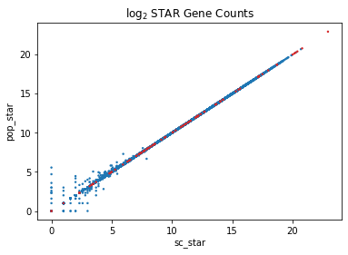

```python
plot_star()
```

Summing the STAR uniquely mapping single cell reads worked really well.

# Compare SmartSeq Salmon gene counts and TPMs with and without decoy

```python
def plot_salmon_genes():
    size = 3
    f = pyplot.figure(figsize=(10,4))
    ax = f.add_subplot(1,2,1)
    ax.scatter(gene_counts_log2['pop_salmon_decoy'], gene_counts_log2['pop_salmon'], color=gene_color, s=size)
    _ = ax.set_ylabel('pop_salmon_decoy')
    _ = ax.set_xlabel('pop_salmon')
    plot_y_eq_x(ax)
    ax.set_title('log$_2$ Salmon Gene Counts')
    ax = f.add_subplot(1,2,2)
    _ = ax.scatter(gene_tpms_log2['pop_salmon_decoy'], gene_tpms_log2['pop_salmon'], color=gene_color, s=size)
    _ = ax.set_ylabel('pop_salmon_decoy')
    _ = ax.set_xlabel('pop_salmon')
    _ = ax.set_title('log$_2$ Salmon Gene TPMs')
    plot_y_eq_x(ax)
```

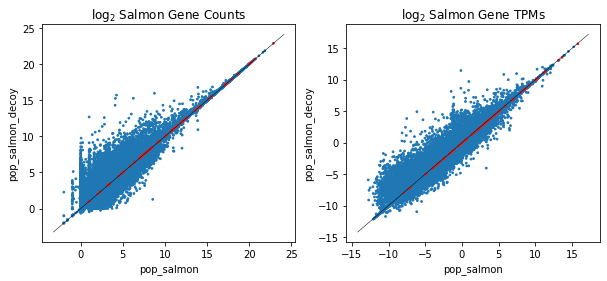

```python
plot_salmon_genes()
```

Decoy does do something, and my first attempt at building these slides was wrong, and this is more correct

# Compare SmartSeq Salmon transcript counts and TPMs with and without decoy

```python
def plot_salmon_transcripts():
    size = 3
    f = pyplot.figure(figsize=(10,4))
    ax = f.add_subplot(1,2,1)
    ax.scatter(transcript_counts_log2['pop_salmon_decoy'], transcript_counts_log2['pop_salmon'], color=transcript_color, s=size)
    _ = ax.set_ylabel('pop_salmon_decoy')
    _ = ax.set_xlabel('sc_salmon')
    _ = ax.set_title('log$_2$ Transcript Counts')
    plot_y_eq_x(ax)
    ax = f.add_subplot(1,2,2)
    ax.scatter(transcript_tpms_log2['pop_salmon_decoy'], transcript_tpms_log2['pop_salmon'], color=transcript_color, s=size)
    _ = ax.set_ylabel('pop_salmon_decoy')
    _ = ax.set_xlabel('sc_salmon')
    _ = ax.set_title('log$_2$ Transcript TPMs')
    plot_y_eq_x(ax)
```

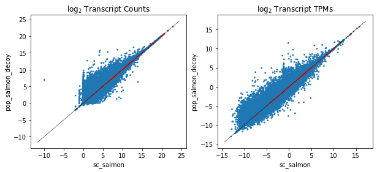

```python
plot_salmon_transcripts()
```

# Compare Gene Counts

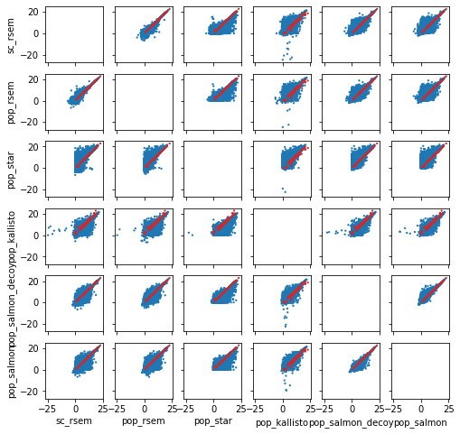

```python
columns = ['sc_rsem', 'pop_rsem', 'pop_star', 'pop_kallisto', 'pop_salmon_decoy', 'pop_salmon']; f = scatter_matrix(gene_counts_log2, gene_color, columns)
```

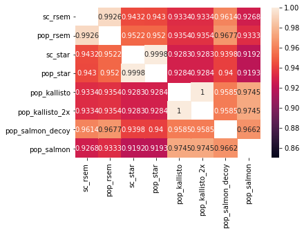

```python
_ = seaborn.heatmap(gene_count_scores['rafa_spearman'], annot=True, fmt='.4g', vmin=vmin, vmax=1.0)
```

# Compare Gene TPMs

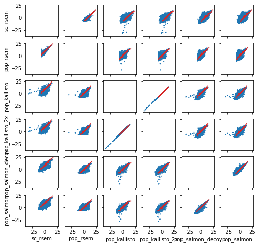

```python
f = scatter_matrix(gene_tpms_log2, gene_color)
```

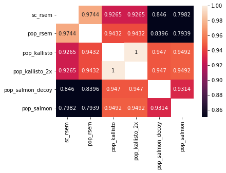

```python
_ = seaborn.heatmap(gene_tpm_scores['rafa_spearman'], annot=True, fmt='.4g', vmin=vmin, vmax=1.0)
```

# Compare Transcript Counts

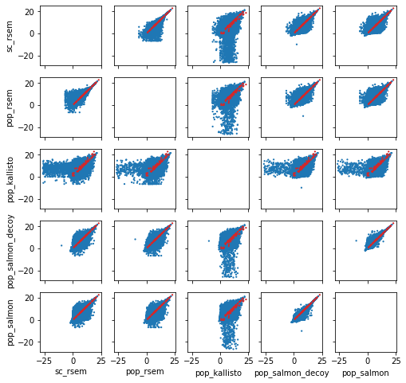

```python
f = scatter_matrix(transcript_counts_log2, transcript_color, columns=['sc_rsem', 'pop_rsem', 'pop_kallisto', 'pop_salmon_decoy', 'pop_salmon'])
```

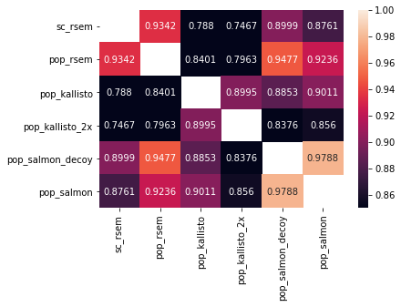

```python
_ = seaborn.heatmap(transcript_count_scores['rafa_spearman'], annot=True, fmt='.4g', vmin=vmin, vmax=1.0)
```

# Compare Transcript TPMs

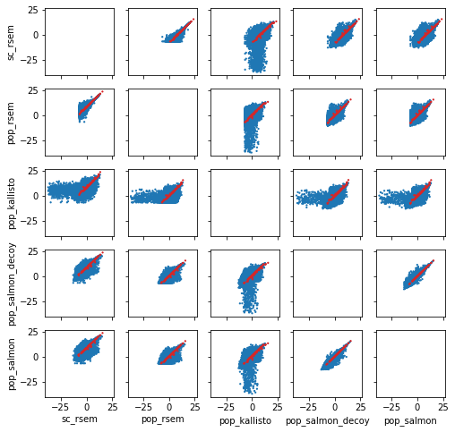

```python
f = scatter_matrix(transcript_tpms_log2, transcript_color, columns=['sc_rsem', 'pop_rsem', 'pop_kallisto', 'pop_salmon_decoy', 'pop_salmon'])
```

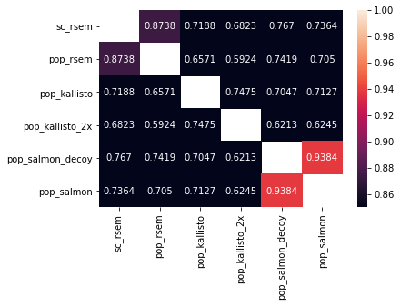

```python
_ = seaborn.heatmap(transcript_tpm_scores['rafa_spearman'], annot=True, fmt='.4g', vmin=vmin, vmax=1.0)
```

# Highlight Kallisto

Zoom in on kallisto versus other algorithms.

In the following plots the one furthest to the right is RSEM vs Salmon (without decoy)

## Plot Kallisto Gene Counts

```python
def plot_kallisto_gene_counts():
    size = 3
    f = pyplot.figure(figsize=(14,6))
    f.suptitle('log$_2$ Gene Counts')
    axes = f.subplots(1,4, sharey=True, sharex=True)
    axes[0].scatter(gene_counts_log2['pop_kallisto'], gene_counts_log2['pop_rsem'], color=gene_color, s=size)
    _ = axes[0].set_ylabel('pop_kallisto')
    _ = axes[0].set_xlabel('pop_rsem')
    plot_y_eq_x(axes[0])
    #ax = f.add_subplot(1,3,2)
    axes[1].scatter(gene_counts_log2['pop_kallisto'], gene_counts_log2['pop_star'], color=gene_color, s=size)
    _ = axes[1].set_ylabel('pop_kallisto')
    _ = axes[1].set_xlabel('pop_star')
    #ax = f.add_subplot(1,3,3)
    plot_y_eq_x(axes[1])
    axes[2].scatter(gene_counts_log2['pop_kallisto'], gene_counts_log2['pop_salmon'], color=gene_color, s=size)
    _ = axes[2].set_ylabel('pop_kallisto')
    _ = axes[2].set_xlabel('pop_salmon')
    plot_y_eq_x(axes[2])

    axes[3].scatter(gene_counts_log2['pop_rsem'], gene_counts_log2['pop_salmon'], color=gene_color, s=size)
    _ = axes[3].set_xlabel('pop_rsem')
    _ = axes[3].set_ylabel('pop_salmon')
    plot_y_eq_x(axes[3])
```

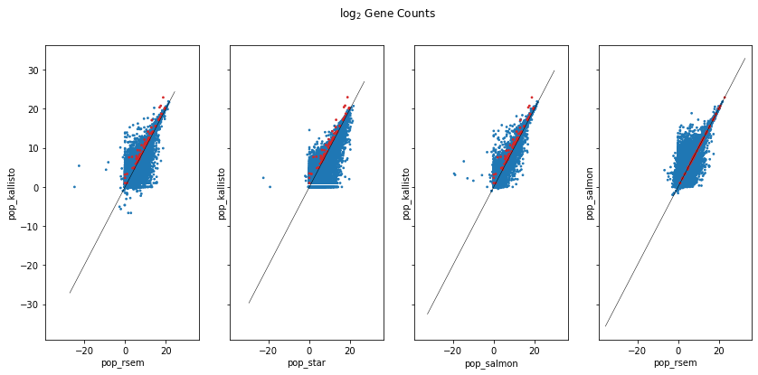

```python
plot_kallisto_gene_counts()
```

## Kallisto Gene TPMs

```python
def plot_kallisto_gene_tpm():
    size = 3
    f = pyplot.figure(figsize=(12,6))
    f.suptitle('log$_2$ Gene Counts')
    axes = f.subplots(1,3, sharey=True, sharex=True)
    axes[0].scatter(gene_tpms_log2['pop_kallisto'], gene_tpms_log2['pop_rsem'], color=gene_color, s=size)
    _ = axes[0].set_ylabel('pop_kallisto')
    _ = axes[0].set_xlabel('pop_rsem')
    plot_y_eq_x(axes[0])
    #ax = f.add_subplot(1,3,2)
    axes[1].scatter(gene_tpms_log2['pop_kallisto'], gene_tpms_log2['pop_salmon'], color=gene_color, s=size)
    _ = axes[1].set_ylabel('pop_kallisto')
    _ = axes[1].set_xlabel('pop_salmon')
    #ax = f.add_subplot(1,3,3)
    plot_y_eq_x(axes[1])
    axes[2].scatter(gene_tpms_log2['pop_rsem'], gene_tpms_log2['pop_salmon'], color=gene_color, s=size)
    #_ = ax.set_ylabel('pop_kallisto')
    _ = axes[2].set_xlabel('pop_rsem')
    _ = axes[2].set_ylabel('pop_salmon')
    plot_y_eq_x(axes[2])
```

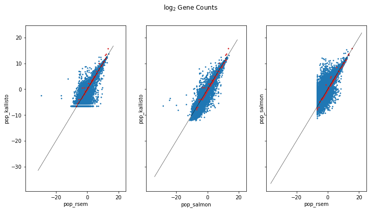

```python
plot_kallisto_gene_tpm()
```

## Kallisto Transcript Counts

```python
def plot_kallisto_transcript_counts():
    size = 3
    f = pyplot.figure(figsize=(10,6))
    f.suptitle('log$_2$ Transcript Counts')

    axes = f.subplots(1,3, sharex=True, sharey=True)
    axes[0].scatter(transcript_counts_log2['pop_kallisto'], transcript_counts_log2['pop_rsem'], color=transcript_color, s=size)
    _ = axes[0].set_ylabel('pop_kallisto')
    _ = axes[0].set_xlabel('pop_rsem')
    plot_y_eq_x(axes[0])
    #_ = axes[0].set_title('log$_2$ Transcript Counts')
    axes[1].scatter(transcript_counts_log2['pop_kallisto'], transcript_counts_log2['pop_salmon'], color=transcript_color, s=size)
    _ = axes[1].set_ylabel('pop_kallisto')
    _ = axes[1].set_xlabel('pop_salmon')
    plot_y_eq_x(axes[1])
    axes[2].scatter(transcript_counts_log2['pop_rsem'], transcript_counts_log2['pop_salmon'], color=transcript_color, s=size)
    _ = axes[2].set_xlabel('pop_rsem')
    _ = axes[2].set_ylabel('pop_salmon')
    plot_y_eq_x(axes[2])
```

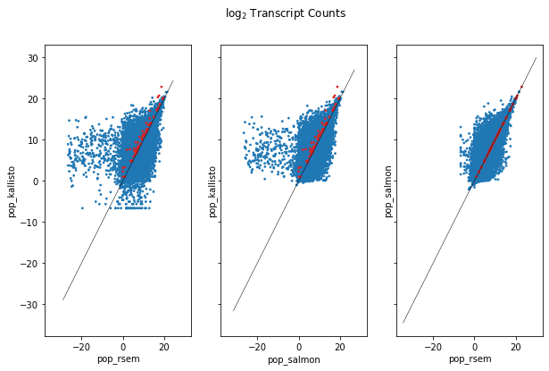

```python
plot_kallisto_transcript_counts()
```

```python
def plot_kallisto_transcript_tpms():
    size = 3
    f = pyplot.figure(figsize=(10,4))
    f.suptitle('log$_2$ Transcript TPMs')

    axes = f.subplots(1,3, sharex=True, sharey=True)
    axes[0].scatter(transcript_counts_log2['pop_kallisto'], transcript_counts_log2['pop_rsem'], color=transcript_color, s=size)
    _ = axes[0].set_ylabel('pop_kallisto')
    _ = axes[0].set_xlabel('pop_rsem')
    plot_y_eq_x(axes[0])
    #_ = axes[0].set_title('log$_2$ Transcript Counts')
    axes[1].scatter(transcript_counts_log2['pop_kallisto'], transcript_counts_log2['pop_salmon'], color=transcript_color, s=size)
    _ = axes[1].set_ylabel('pop_kallisto')
    _ = axes[1].set_xlabel('pop_salmon')
    plot_y_eq_x(axes[1])
    axes[2].scatter(transcript_counts_log2['pop_rsem'], transcript_counts_log2['pop_salmon'], color=transcript_color, s=size)
    _ = axes[2].set_xlabel('pop_rsem')
    _ = axes[2].set_ylabel('pop_salmon')
    plot_y_eq_x(axes[2])
```

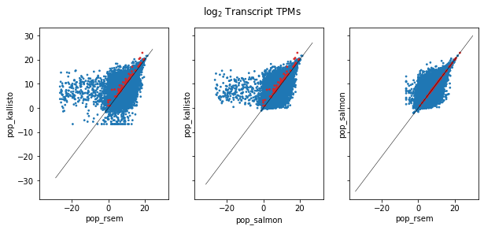

```python
plot_kallisto_transcript_tpms()
```

# Conclusions

- What's with Kallisto's small values?
- Kallisto seems to have more trouble quantifying the ERCC spikes
- It really looks like if you're happy with gene counts, STAR's ReadsPerGenes is better than either kallisto or salmon
- Salmon looks especially bad for gene TPMs, but does pretty well with transcript counts.
- On the whole counts look more reliable than TPMs.

# Bonus

Show that kallisto has some oddly small values. This is with filtering out all the -inf from log2 of 0.

```python
c = 'pop_kallisto'
gene_counts_log2[(gene_counts_log2[c] < -5) & numpy.isfinite(gene_counts_log2[c])]
```

| gene_id | sc_rsem | pop_rsem | sc_star | pop_star | pop_kallisto | pop_kallisto_2x | pop_salmon_decoy | pop_salmon |
| --- | --- | --- | --- | --- | --- | --- | --- | --- |
| ENSMUSG00000040540.6 | 8.326385 | 5.399855 | 2.321928 | 2.321928 | -22.555883 | -22.555883 | 2.496718 | -inf |
| ENSMUSG00000045868.12 | 5.239169 | -inf | -inf | -inf | -14.757222 | -14.757222 | -inf | -inf |
| ENSMUSG00000068252.6 | -inf | -inf | -inf | -inf | -14.662270 | -14.662270 | 1.584962 | 6.545073 |
| ENSMUSG00000073723.10 | -inf | -inf | -inf | -inf | -7.947629 | -7.947629 | -inf | -inf |
| ENSMUSG00000078922.9 | -inf | -inf | -inf | -inf | -10.434895 | -10.434895 | -inf | -inf |
| ENSMUSG00000079156.11 | -inf | -inf | -inf | -inf | -6.246502 | -6.246502 | -inf | -inf |
| ENSMUSG00000085060.1 | -inf | -inf | -inf | -inf | -19.408127 | -19.408127 | -inf | 3.411019 |
| ENSMUSG00000086974.1 | -inf | -inf | -inf | -inf | -6.349968 | -6.349968 | -inf | -inf |
| ENSMUSG00000090265.1 | -inf | -inf | -inf | -inf | -12.876265 | -12.876265 | 2.189983 | 2.200065 |
| ENSMUSG00000093924.1 | 1.063503 | -inf | -inf | -inf | -20.768539 | -20.768539 | 2.893556 | -inf |
| ENSMUSG00000094404.1 | -inf | -inf | -inf | -inf | -5.233754 | -5.233754 | -inf | -inf |
| ENSMUSG00000094507.1 | -inf | -inf | -inf | -inf | -5.233754 | -5.233754 | -inf | -inf |
| ENSMUSG00000094911.1 | -inf | -inf | -inf | -inf | -5.233754 | -5.233754 | -inf | -inf |
| ENSMUSG00000094939.1 | -inf | -inf | -inf | -inf | -5.233754 | -5.233754 | -inf | -inf |
| ENSMUSG00000094945.3 | 4.459432 | 4.404631 | -inf | -inf | -9.309352 | -9.309352 | 4.501121 | -inf |
| ENSMUSG00000095019.1 | -inf | -inf | -inf | -inf | -5.233754 | -5.233754 | -inf | -inf |
| ENSMUSG00000095074.4 | -inf | -inf | -inf | -inf | -8.246246 | -8.246246 | -inf | -inf |
| ENSMUSG00000095474.1 | 6.951634 | -inf | -inf | -inf | -24.159452 | -24.159452 | -inf | -inf |
| ENSMUSG00000095869.1 | 4.005400 | -inf | -inf | -inf | -14.220980 | -14.220980 | 3.568640 | -inf |
| ENSMUSG00000096379.1 | -inf | -inf | -inf | -inf | -5.233754 | -5.233754 | -inf | -inf |
| ENSMUSG00000099951.1 | -inf | -inf | -inf | -inf | -23.205595 | -23.205595 | -inf | -inf |
| ENSMUSG00000101023.1 | -inf | -inf | -inf | -inf | -19.461142 | -19.461142 | -inf | -inf |
| ENSMUSG00000101847.1 | -inf | -inf | -inf | -inf | -25.075026 | -25.075026 | -inf | -inf |
| ENSMUSG00000103218.1 | -inf | -inf | -inf | -inf | -5.742833 | -5.742833 | 4.155830 | 3.013105 |
| ENSMUSG00000103909.1 | -inf | -inf | -inf | -inf | -19.462370 | -19.462370 | -inf | -inf |
| ENSMUSG00000105114.1 | -inf | -inf | -inf | -inf | -6.377783 | -6.377783 | 0.800745 | -inf |
| ENSMUSG00000105340.5 | 4.162694 | -inf | 0.000000 | 0.000000 | -19.267942 | -19.267942 | -inf | -inf |
| ENSMUSG00000106144.1 | 6.287805 | 6.307975 | -inf | -inf | -8.210610 | -8.210610 | -inf | -inf |
| ENSMUSG00000106582.1 | -inf | -inf | -inf | -inf | -18.926937 | -18.926937 | -inf | 3.076217 |
| ENSMUSG00000107018.1 | 0.000000 | 0.000000 | -inf | -inf | -24.770447 | -24.770447 | -inf | -inf |
| ENSMUSG00000109976.1 | -inf | -inf | -inf | -inf | -9.967100 | -9.967100 | -inf | 1.584962 |
| ENSMUSG00000112916.1 | -inf | -inf | -inf | -inf | -5.606151 | -5.606151 | -inf | -inf |
| ENSMUSG00000113857.1 | -inf | -inf | -inf | -inf | -14.095382 | -14.095382 | -inf | -inf |
| ENSMUSG00000114187.1 | -inf | -inf | -inf | -inf | -22.196907 | -22.196907 | -inf | -inf |
| ENSMUSG00000114582.1 | -inf | -inf | -inf | -inf | -10.046075 | -10.046075 | -inf | -inf |

```python
spikes_path = Path('~/proj/single-cell-qc/singleqc/ENCSR722NWD.tsv').expanduser()
spikes = pandas.read_csv(spikes_path, sep='\t', index_col='gene_id')

spikes
```

| gene_id | length | concentration |
| --- | --- | --- |
| gSpikein_ERCC-00002 | 1061 | 1806.000000 |
| gSpikein_ERCC-00003 | 1023 | 112.875000 |
| gSpikein_ERCC-00004 | 523 | 903.000000 |
| gSpikein_ERCC-00009 | 984 | 112.875000 |
| gSpikein_ERCC-00012 | 994 | 0.013779 |
| ... | ... | ... |
| gSpikein_ERCC-00164 | 1022 | 0.055115 |
| gSpikein_ERCC-00165 | 872 | 7.054688 |
| gSpikein_ERCC-00168 | 1024 | 0.055115 |
| gSpikein_ERCC-00170 | 1023 | 1.763672 |
| gSpikein_ERCC-00171 | 505 | 451.500000 |

92 rows × 2 columns

[output not shown]

[figure not shown]

```python
def plot_polyfit(ax, x, y):
    m, b = numpy.polyfit(x.reindex(y.index), y, 1)
    def line(x):
        return m * x + b
    def yline(y):
        return (y-b)/m

    ax.plot([0, yline(y.max())], [line(0), y.max()])

def plot_spikein_counts():
    size = 3
    f = pyplot.figure(figsize=(10,6))
    #f.suptitle('log$_2$ Transcript Counts')
    axes = f.subplots(1,3, sharex=True, sharey=True)

    axes[0].scatter(gene_counts_log2['pop_kallisto'].reindex(spikes.index), numpy.log2(spikes['concentration']), color='r', s=size)
    _ = axes[0].set_xlabel('pop_kallisto')
    _ = axes[0].set_ylabel('spike concentrations')
    plot_polyfit(axes[0], gene_counts_log2['pop_kallisto'].reindex(spikes.index), numpy.log2(spikes['concentration']))
    #plot_y_eq_x(axes[0])
    axes[1].scatter(gene_counts_log2['pop_salmon'].reindex(spikes.index), numpy.log2(spikes['concentration']), color='r', s=size)
    _ = axes[1].set_xlabel('pop_salmon')
    _ = axes[1].set_ylabel('spike concentrations')
    plot_polyfit(axes[1], gene_counts_log2['pop_salmon'].reindex(spikes.index), numpy.log2(spikes['concentration']))
    #plot_y_eq_x(axes[1])
    axes[2].scatter(gene_counts_log2['pop_rsem'].reindex(spikes.index), numpy.log2(spikes['concentration']), color='r', s=size)
    _ = axes[2].set_xlabel('pop_rsem')
    _ = axes[2].set_ylabel('spike concentrations')
    plot_polyfit(axes[2], gene_counts_log2['pop_rsem'].reindex(spikes.index), numpy.log2(spikes['concentration']))

    #plot_y_eq_x(axes[2])

plot_spikein_counts()
```

```python
def plot_polyfit_residual(ax, x, y):
    (m, b), residual, rank, singular_values, rcond = numpy.polyfit(x.reindex(y.index), y, 1, full=True)
    def line(x):
        return m * x + b
    def yline(y):
        return (y-b)/m

    ax.plot([0, yline(y.max())], [line(0), y.max()])
    #x0, x1 = ax.get_xlim()
    #ax.text((x1-x0)/2, y.max(), 'Residual {}'.format(residual))
    ax.set_title('Residual {:.3}'.format(float(residual)))

def plot_spikein_counts():
    size = 3
    f = pyplot.figure(figsize=(10,6))
    #f.suptitle('log$_2$ Transcript Counts')
    axes = f.subplots(1,3, sharex=True, sharey=True)

    axes[0].scatter(gene_counts['pop_kallisto'].reindex(spikes.index), spikes['concentration'], color='r', s=size)
    _ = axes[0].set_xlabel('pop_kallisto')
    _ = axes[0].set_ylabel('spike concentrations')
    plot_polyfit_residual(axes[0], gene_counts['pop_kallisto'].reindex(spikes.index), spikes['concentration'])
    #plot_y_eq_x(axes[0])
    axes[1].scatter(gene_counts['pop_salmon'].reindex(spikes.index), spikes['concentration'], color='r', s=size)
    _ = axes[1].set_xlabel('pop_salmon')
    _ = axes[1].set_ylabel('spike concentrations')
    plot_polyfit_residual(axes[1], gene_counts['pop_salmon'].reindex(spikes.index), spikes['concentration'])
    #plot_y_eq_x(axes[1])
    axes[2].scatter(gene_counts['pop_rsem'].reindex(spikes.index), spikes['concentration'], color='r', s=size)
    _ = axes[2].set_xlabel('pop_rsem')
    _ = axes[2].set_ylabel('spike concentrations')
    plot_polyfit_residual(axes[2], gene_counts['pop_rsem'].reindex(spikes.index), spikes['concentration'])

    #plot_y_eq_x(axes[2])

plot_spikein_counts()
```

```python
p, residual, rank, singular_values, rcond = numpy.polyfit(gene_counts['pop_rsem'].reindex(spikes.index), spikes['concentration'], 1, full=True)
p, residual
```

```python
numpy.polyfit(gene_counts['pop_rsem'].reindex(spikes.index), spikes['concentration'], 1)
```